# Lecture 5: Message authentication codes

### Announcements

- Please pick up your card
- Due Friday 9/19 on Gradescope
  - Reading Assessment 2, covering [PPG sections 13.1-13.2](https://ezproxy.bu.edu/login?url=https://link.springer.com/content/pdf/10.1007/978-3-662-69007-9_13)
  - Homework 2

### Learning outcomes

By the end of today’s lecture, you will learn:

- How Bob can detect whether a message received over the Internet was sent by Alice
- How we write formal definitions for crypto primitives, such as MACs
- How HMAC works, and why it addresses a limitation of SHA-2

### Review from last lecture

Every cryptosystem attempts to provide some or all of the “CIA triad.”

- **C**onfidentiality: hiding data
- **I**ntegrity: preventing or detecting tampering of data
- **A**vailability: preventing censorship of data

A **pseudorandom** generator is:

- A *deterministic* procedure that produces a lot of data from a short seed
- But it looks *random* to an outsider who does not know the seed

Using a cryptographic hash function and a seed $k$, we can *pseudorandomly* generate many secrets
$$H(k, 0), H(k, 1), H(k, 2), \ldots$$

This idea is effective thanks to the properties of the underlying hash function.

- Because $H$ is preimage-resistant, even if one secret (say, $H(k, 2)$) happens to be revealed to the world, nobody can use it to reverse-engineer the main seed $r$
- Because $H$ acts like a random oracle, the rows of the truth table of $H$ appear to be independent, so no two secrets have any discernible connection to each other

The actual function you need to run here is not quite $H$, but rather a slightly more complicated construction called `HMAC` applied to the hash function.

## 5.1 Network integrity

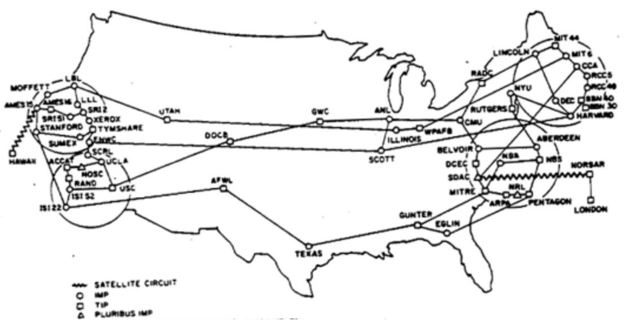

The early Internet (source: [pwnallthethings on Twitter](https://twitter.com/pwnallthethings/status/935395453482520576))

Here is our motivating question for today:

> On the Internet, how do Alice and Bob know that they are talking to each other?
- They could send their names to each other, but a malicious Mallory could **forge** that
- They could ask a common friend, but what if that friend turns out to be a malicious Mallory?

> “Cryptography is how people get things done when they need one another, don’t fully trust one another, and have adversaries actively trying to screw things up.”

> – Ben Adida

To simplify things for today:

- Suppose that Alice and Bob physically meet one time (they can perform any action that you want)
- Afterward, they want to be able to recognize each other over the Internet

**Question.** How would you solve this problem?

**Construction.** Here is one solution attempt that relies on *pseudorandomness*.

- When Alice and Bob physically meet, they jointly create a random seed $k$
- They agree to keep $k$ secret from the rest of the world
- The first time Alice wants to send a message $m_1$ to Bob, she appends the string $H(k, 1)$
- The second time Alice wants to send a message $m_2$ to Bob, she appends the string $H(k, 2)$
- …

**Interactive Question.** Does this construction guarantee to Bob that the message came from Alice?

1. Yes
2. No

**Answer.** No

- Good news: Mallory cannot predict $H(k, 1)$ before Alice sends it
- Also even given $H(k, 1)$, Mallory cannot predict $H(k, 2)$
- Bad news: once Alice sends $m_1$ and $H(k, 1)$ over the Internet, Mallory can intercept it and substitute her own message $m_1^*$

**New construction.** Let’s make a small change to the prior attempt.

- When Alice and Bob physically meet, they jointly create a random seed $k$
- Whenever Alice wants to send a message $m$ to Bob, she appends the string $H(k, m)$

**Interactive Question.** Does the new construction guarantee to Bob that the message came from Alice?

1. Yes
2. No

**Answer.** Yes, this should work! (Well, subject to some caveats about the hash function $H$ design that we will discuss later today.)

### Terminology

Let’s take a moment to appreciate what we have built.

- Alice and Bob created a secret *code* that only they can understand
- Using this code, they can *authenticate* the sender of *messages* that they receive

Accordingly, this primitive is referred to by cryptographers as a **message authentication code**, or MAC.

The appended data $H(k, m)$ is called the **tag** of the message $m$.

Also, the long-lived seed bytestring $k$ is called a **secret key** (often abbreviated *sk*).

[figure not shown]

Internet communication

- Both Alice and Bob remember the same key $k$
- For this reason, $k$ is sometimes called a **symmetric key**
- But they must never share $k$ with anyone else!
- If Alice wants to talk to Carol, they must choose a different key

## 5.2 Defining MACs

Let’s define the *operations* and security *requirements* for a MAC.

**Interactive Question.** How many operations do Alice and Bob need? That is, if you were to write a Python class `MAC` to run everything in our New Construction, then how many methods (i.e., functions) would you write?

1. 1
2. 2
3. 3
4. 4

### Informal definitions

Informally, a MAC has three operations.

- Alice and Bob choose a secret key (this must be randomized)
- Alice adds a tag to the message before sending it (ideally, the tag is short)
- Bob verifies the tag after receiving it (this must be deterministic)

Informally, a MAC has two requirements.

- **Correctness**: honest receiver Bob can verify that Alice was the sender of the message and that the message was not tampered in transit
- **Unforgeability**: the tag is bound to the message, and Mallory cannot use it to *forge* a tag for any other message

There are also three limitations of MACs.

- **Replay attacks**: if Alice sends a message + tag to Bob and he verifies it, then Mallory can later re-send the same message + tag and it will pass Bob’s verification check again
- **Staleness**: if Alice sends a message + tag but Mallory intercepts it in transit, then Mallory can deliver it days/months/years later and it will pass Bob’s verification check
- **Reveals messages**: MACs do not attempt to hide the message $m$ (we will need encryption for that)

### Formal definitions

Now, let’s use math to specify the operations and requirements more precisely.

**Definition 1 (MAC)** A *message authentication code* contains three operations.

- `KeyGen`: takes no input, chooses a secret key $k$ (often, uniformly at random from $\{0,1\}^\kappa$)
- `Tag`${}_k(m)$: produces a tag $t \in \{0, 1\}^\tau$
- `Verify`${}_k(m, t)$: returns a boolean `true` or `false`

All three operations should be efficiently computable. Moreover, the MAC must satisfy two requirements: correctness and EU-CMA.

- **Correctness** means that for every symmetric secret key produced by `KeyGen`, any output of `Tag` is subsequently accepted by `Verify`.

  In math: $\texttt{Verify}_k( m, \text{Tag}_k(m))=$ `true` for all keys $k$, messages $m$, and randomness used in `Tag` (if any).
- **Existential unforgeability under a chosen message attack** (EU-CMA) is defined using a thought experiment in which Alice plays a game with Mallory. Even after Alice tags many messages of Mallory’s choice, Mallory still cannot forge a tag for a new message.

[figure not shown]

  EU-CMA security game

EU-CMA is a very strong claim: we give Mallory the power to choose

- many, many messages $m_1, m_2, \ldots, m_\ell$ that we will voluntarily tag for her
- which new message $m^*$ and tag $t^*$ she is quizzed on

and she still cannot forge *any* new message and tag with `Verify`${}_k(m^*, t^*) =$`true`

## 5.3 Constructing a MAC

Now that we have formally specified the objectives of a MAC, let’s write our new construction precisely.

- `KeyGen`: Alice and Bob toss coins to choose a uniformly random bytestring $k$
- `Tag`${}_k(m)$: Alice computes $t = H(k, m)$, and she sends $(m, t)$ to Bob
- `Verify`${}_k(m, t')$: Bob checks whether $t' \overset{?}{=} H(k, m)$

**Theorem 1** If $H$ acts like a random oracle, then this MAC construction satisfies Correctness and EU-CMA.

> If an adversary [Mallory] has not explicitly queried the oracle on some point $x$, then the value of $H(x)$ is completely random… at least as far as [Mallory] is concerned.

> – Jon Katz and Yehuda Lindell, *Introduction to Modern Cryptography*

Note that this is a **conditional** theorem: the MAC is secure if the hash function is.

This is a powerful idea that cryptographers use to build many elegant protocols from a few basic primitives that withstand the test of cryptanalysis.

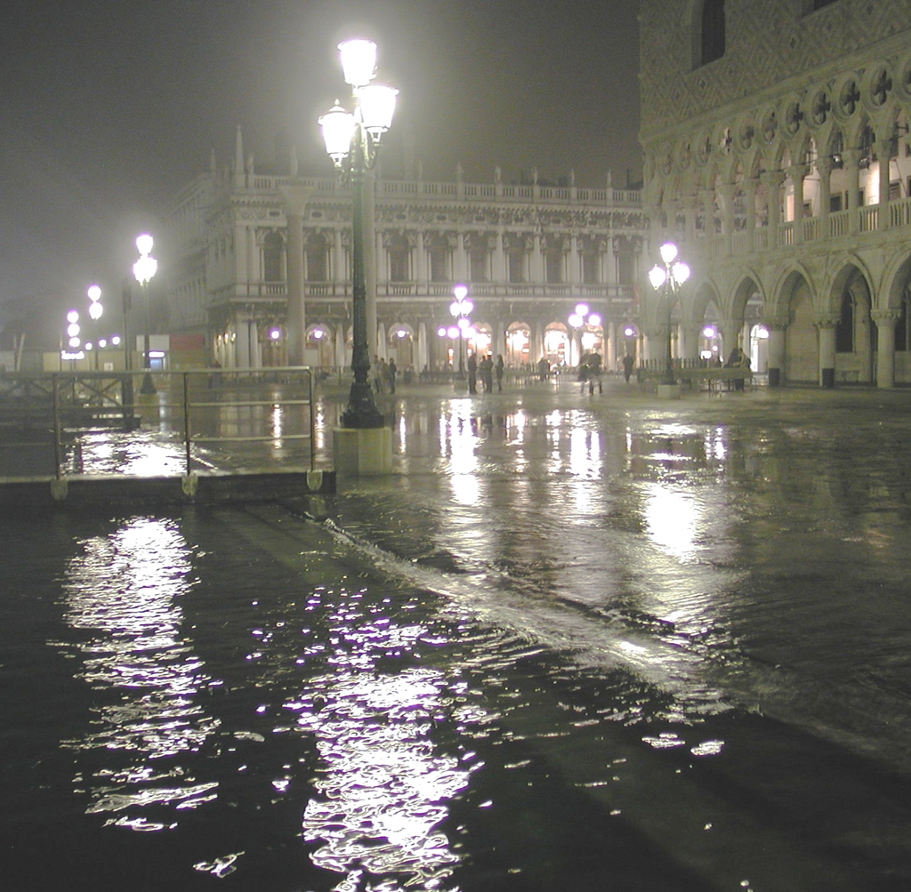

City of Venice, Italy (source: [Wikipedia](https://commons.wikimedia.org/wiki/File:Venezia_acqua_alta_notte_2005_modificata.jpg))

### Design of SHA-2

Here, I need to tell you some important information about the SHA-2 family of hash functions

- Good news: we believe that it is preimage resistant, collision resistant, and puzzle friendly
- Bad news: it does not act like a random oracle because it suffers from *length extension* attacks

SHA-256 uses a *Merkle–Damgård construction* with two parts:

- a random-looking compression function $C$ of fixed length (64 $\to$ 32 bytes)
- an iterative design that repeats $C$ as many times as needed (along with a fixed bytestring called an *initialization vector* used at the very beginning)

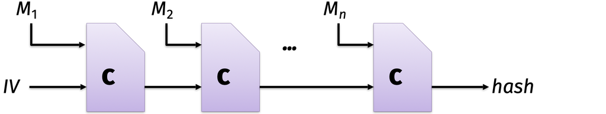

While this design has many benefits, it is vulnerable to a **length extension** attack.

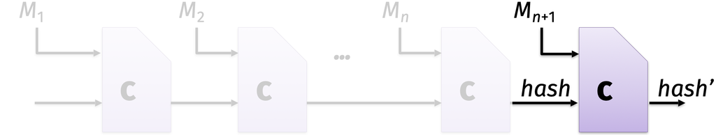

Intuitively, the issue is that Mallory could extend

$$H(k, \texttt{ b"Hello"}) \longrightarrow H(k, \texttt{ b"Hello world"})$$

without ever knowing $k$. This would break the MAC’s unforgeability.

### HMAC

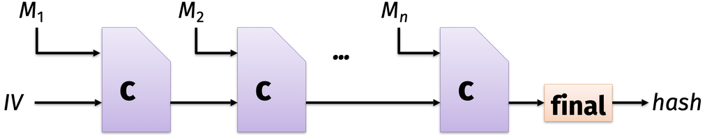

Finalization

Now that we understand the problem, the fix is simple—just do something different at the end to stop length extensions. This is called *finalization*.

- Bitcoin runs the entire SHA-256 function a second time
- When designing a MAC (which has a key), it suffices to run one more iteration of the compression function $C$ with a different key

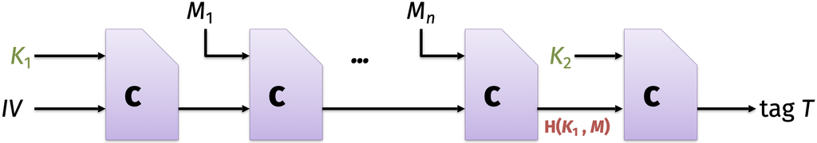

NMAC construction

This construction comes from a [1996 paper](https://cseweb.ucsd.edu/~mihir/papers/kmd5.pdf) by Mihir Bellare, Ran Canetti, and Hugo Krawczyk.

Using some clever tricks, they also designed a variant called **HMAC** that only needs one key. That’s what everyone uses today.

**Theorem 2** If the compression function $C$ is pseudorandom, then HMAC satisfies Correctness and EU-CMA. (The proof is in [this paper](https://eprint.iacr.org/2006/043.pdf) by Mihir Bellare.)

### Putting everything together

Here is our final MAC construction.

- `KeyGen`: sample a uniformly random bytestring $k$ that is 256 bits (32 bytes) long
- `Tag`${}_k(m)$: compute $t = \texttt{HMAC}(k, m)$
- `Verify`${}_k(m, t')$: return `true` if $t' =\texttt{HMAC}(k, m)$, otherwise return `false`

MACs are used *everywhere* to protect data at rest in file systems and in transit over the Internet. Modern cryptography follows the **Cryptographic Doom Principle**:

> “If you have to perform any cryptographic operation before verifying the MAC on a message you’ve received, it will somehow inevitably lead to doom!” – Moxie Marlinspike

But going back to the start of today’s lecture, we made one simplifying assumption.

> Suppose that Alice and Bob physically meet one time

This raises the question: how do Alice and Bob communicate over the Internet if they have never met before to exchange the symmetric secret key $k$? We will study this topic next week.